# College Enrollment Odds Among Black Students: A Logit Model

William Kyeremateng

May 05, 2019

[figure not shown]

Source: www.redbubble.com

## 1. Introduction

This project examine the factors that may account for the differences in college enrollment odds among black people. Native born Blacks. Literature on the topic shows that in the Black community (everyone considered as having African origins), college enrollment rates for students with immigrant parents are higher than those for students with parents born in the U.S. Understanding this question may help measure the scale of societal discrimination versus other factors that account for the education success gap.

Among a number of others, this analysis seeks to mainly answer the question: **is there a difference in college enrollment odds between children from US-born Black households and those from immigrants households?** Lower college enrollment rates for students with native-born Black parents than Black students with immigrant parents would imply that discrimination alone does not explain the success gap.

## 2. Data

The data used in this project comes from the Current Population Survey (CPS) - a monthly survey of U.S. households conducted by the Bureau of Labor Statistics for the Census Bureau. The CPS data used here is from the March 2013 survey and was accessed through the IPUMS project of the Minnesota Population Center at the University of Minnesota.

Before uploading the I load the packages containing the various functions we will be using for the analysis. They include `tidyverse`, `visdat`, `summarytools`, `plotly`, among others.

Let’s upload the data.

Here are the top and bottom rows of the data.

### Head

| STATEFIP | AGE | SEX | RACE | MARST | ASIAN | BPL | CITIZEN | NATIVITY | HISPAN | EMPSTAT | LABFORCE | EDUC99 | SCHLCOLL | FTOTVAL | OFFPOV | POVERTY | GOTWIC | HOURWAGE | SEX_HEAD | RACE_HEAD | MARST_HEAD | BPL_HEAD | CITIZEN_HEAD | NATIVITY_HEAD | HISPAN_HEAD | LABFORCE_HEAD | EDUC99_HEAD | FTOTVAL_HEAD | OFFPOV_HEAD | … |
| --- | --- | --- | --- | --- | --- | --- | --- | --- | --- | --- | --- | --- | --- | --- | --- | --- | --- | --- | --- | --- | --- | --- | --- | --- | --- | --- | --- | --- | --- | --- |
| 23 | 57 | 1 | 100 | 4 | 99 | 9900 | 1 | 1 | 0 | 32 | 1 | 10 | 0 | 20196 | 2 | 23 | 0 | 999.99 | 1 | 100 | 4 | 9900 | 1 | 1 | 0 | 1 | 10 | 20196 | 2 | … |
| 23 | 45 | 2 | 100 | 1 | 99 | 9900 | 1 | 1 | 0 | 10 | 2 | 11 | 5 | 64400 | 2 | 23 | 1 | 14.38 | 2 | 100 | 1 | 9900 | 1 | 1 | 0 | 2 | 11 | 64400 | 2 | … |
| 23 | 40 | 1 | 100 | 1 | 99 | 9900 | 1 | 1 | 0 | 10 | 2 | 13 | 5 | 64400 | 2 | 23 | 0 | 10.50 | 2 | 100 | 1 | 9900 | 1 | 1 | 0 | 2 | 11 | 64400 | 2 | … |
| 23 | 66 | 1 | 100 | 5 | 99 | 9900 | 1 | 1 | 0 | 32 | 1 | 7 | 0 | 64400 | 2 | 23 | 0 | 999.99 | 2 | 100 | 1 | 9900 | 1 | 1 | 0 | 2 | 11 | 64400 | 2 | … |
| 23 | 59 | 1 | 100 | 1 | 99 | 9900 | 1 | 1 | 0 | 12 | 2 | 10 | 0 | 9000 | 1 | 10 | 0 | 999.99 | 1 | 100 | 1 | 9900 | 1 | 1 | 0 | 2 | 10 | 9000 | 1 | … |

### Tail

| STATEFIP | AGE | SEX | RACE | MARST | ASIAN | BPL | CITIZEN | NATIVITY | HISPAN | EMPSTAT | LABFORCE | EDUC99 | SCHLCOLL | FTOTVAL | OFFPOV | POVERTY | GOTWIC | HOURWAGE | SEX_HEAD | RACE_HEAD | MARST_HEAD | BPL_HEAD | CITIZEN_HEAD | NATIVITY_HEAD | HISPAN_HEAD | LABFORCE_HEAD | EDUC99_HEAD | FTOTVAL_HEAD | OFFPOV_HEAD | … |
| --- | --- | --- | --- | --- | --- | --- | --- | --- | --- | --- | --- | --- | --- | --- | --- | --- | --- | --- | --- | --- | --- | --- | --- | --- | --- | --- | --- | --- | --- | --- |
| 15 | 44 | 2 | 651 | 1 | 70 | 51700 | 4 | 5 | 0 | 10 | 2 | 17 | 5 | 145000 | 2 | 23 | 0 | 999.99 | 1 | 651 | 1 | 50100 | 3 | 5 | 0 | 2 | 16 | 145000 | 2 | … |
| 15 | 10 | 2 | 651 | 6 | 70 | 51700 | 4 | 5 | 0 | 0 | 0 | 0 | 0 | 145000 | 2 | 23 | 0 | 999.99 | 1 | 651 | 1 | 50100 | 3 | 5 | 0 | 2 | 16 | 145000 | 2 | … |
| 15 | 29 | 1 | 100 | 1 | 99 | 41000 | 4 | 5 | 0 | 10 | 2 | 16 | 5 | 135000 | 2 | 23 | 0 | 999.99 | 1 | 100 | 1 | 41000 | 4 | 5 | 0 | 2 | 16 | 135000 | 2 | … |
| 15 | 29 | 2 | 100 | 1 | 99 | 9900 | 1 | 4 | 0 | 10 | 2 | 16 | 5 | 135000 | 2 | 23 | 0 | 999.99 | 1 | 100 | 1 | 41000 | 4 | 5 | 0 | 2 | 16 | 135000 | 2 | … |
| 15 | 9 | 2 | 100 | 6 | 99 | 9900 | 1 | 2 | 0 | 0 | 0 | 0 | 0 | 135000 | 2 | 23 | 0 | 999.99 | 1 | 100 | 1 | 41000 | 4 | 5 | 0 | 2 | 16 | 135000 | 2 | … |

Now, let us look at the summary and structure of the data.

Data Frame Summary

IPUMS

**Dimensions**: 202634 x 32  
**Duplicates**: 878

| **No** | **Variable** | **Stats / Values** | **Freqs (% of Valid)** | **Graph** | **Valid** | **Missing** |
| --- | --- | --- | --- | --- | --- | --- |
| 1 | STATEFIP [numeric] | Mean (sd) : 27.6 (16.1) min ≤ med ≤ max: 1 ≤ 27 ≤ 56 IQR (CV) : 30 (0.6) | 51 distinct values |  | 202634 (100.0%) | 0 (0.0%) |
| 2 | AGE [numeric] | Mean (sd) : 35.5 (22.3) min ≤ med ≤ max: 0 ≤ 35 ≤ 85 IQR (CV) : 37 (0.6) | 82 distinct values |  | 202634 (100.0%) | 0 (0.0%) |
| 3 | SEX [numeric] | Min : 1 Mean : 1.5 Max : 2 | 1 : 98304 ( 48.5% ) 2 : 104330 ( 51.5% ) |  | 202634 (100.0%) | 0 (0.0%) |
| 4 | RACE [numeric] | Mean (sd) : 167.1 (170.1) min ≤ med ≤ max: 100 ≤ 100 ≤ 830 IQR (CV) : 0 (1) | 26 distinct values |  | 202634 (100.0%) | 0 (0.0%) |
| 5 | MARST [numeric] | Mean (sd) : 3.8 (2.3) min ≤ med ≤ max: 1 ≤ 5 ≤ 6 IQR (CV) : 5 (0.6) | 1 : 79444 ( 39.2% ) 2 : 2121 ( 1.0% ) 3 : 3368 ( 1.7% ) 4 : 15094 ( 7.4% ) 5 : 7926 ( 3.9% ) 6 : 94681 ( 46.7% ) |  | 202634 (100.0%) | 0 (0.0%) |
| 6 | ASIAN [numeric] | Mean (sd) : 95.5 (15) min ≤ med ≤ max: 10 ≤ 99 ≤ 99 IQR (CV) : 0 (0.2) | 10 : 1931 ( 1.0% ) 20 : 2340 ( 1.2% ) 30 : 1906 ( 0.9% ) 40 : 971 ( 0.5% ) 50 : 1004 ( 0.5% ) 60 : 1126 ( 0.6% ) 70 : 2095 ( 1.0% ) 99 : 191261 ( 94.4% ) |  | 202634 (100.0%) | 0 (0.0%) |
| 7 | BPL [numeric] | Mean (sd) : 13428.3 (10549.5) min ≤ med ≤ max: 9900 ≤ 9900 ≤ 96000 IQR (CV) : 0 (0.8) | 162 distinct values |  | 202634 (100.0%) | 0 (0.0%) |
| 8 | CITIZEN [numeric] | Mean (sd) : 1.5 (1.2) min ≤ med ≤ max: 1 ≤ 1 ≤ 5 IQR (CV) : 0 (0.8) | 1 : 173572 ( 85.7% ) 2 : 1211 ( 0.6% ) 3 : 1644 ( 0.8% ) 4 : 11644 ( 5.7% ) 5 : 14563 ( 7.2% ) |  | 202634 (100.0%) | 0 (0.0%) |
| 9 | NATIVITY [numeric] | Mean (sd) : 1.9 (1.5) min ≤ med ≤ max: 0 ≤ 1 ≤ 5 IQR (CV) : 1 (0.8) | 0 : 215 ( 0.1% ) 1 : 149846 ( 73.9% ) 2 : 4846 ( 2.4% ) 3 : 4281 ( 2.1% ) 4 : 14488 ( 7.1% ) 5 : 28958 ( 14.3% ) |  | 202634 (100.0%) | 0 (0.0%) |
| 10 | HISPAN [numeric] | Mean (sd) : 43.7 (129.6) min ≤ med ≤ max: 0 ≤ 0 ≤ 610 IQR (CV) : 0 (3) | 0 : 165314 ( 81.6% ) 100 : 23868 ( 11.8% ) 200 : 3312 ( 1.6% ) 300 : 1172 ( 0.6% ) 600 : 1937 ( 1.0% ) 610 : 7031 ( 3.5% ) |  | 202634 (100.0%) | 0 (0.0%) |
| 11 | EMPSTAT [numeric] | Mean (sd) : 14.9 (13.1) min ≤ med ≤ max: 0 ≤ 10 ≤ 36 IQR (CV) : 22 (0.9) | 0 : 46883 ( 23.1% ) 1 : 654 ( 0.3% ) 10 : 88359 ( 43.6% ) 12 : 3012 ( 1.5% ) 21 : 6579 ( 3.2% ) 22 : 785 ( 0.4% ) 32 : 7806 ( 3.9% ) 34 : 26890 ( 13.3% ) 36 : 21666 ( 10.7% ) |  | 202634 (100.0%) | 0 (0.0%) |
| 12 | LABFORCE [numeric] | Mean (sd) : 1.3 (0.8) min ≤ med ≤ max: 0 ≤ 1 ≤ 2 IQR (CV) : 1 (0.6) | 0 : 47537 ( 23.5% ) 1 : 56362 ( 27.8% ) 2 : 98735 ( 48.7% ) |  | 202634 (100.0%) | 0 (0.0%) |
| 13 | EDUC99 [numeric] | Mean (sd) : 8.7 (5.6) min ≤ med ≤ max: 0 ≤ 10 ≤ 18 IQR (CV) : 8 (0.6) | 16 distinct values |  | 202634 (100.0%) | 0 (0.0%) |
| 14 | SCHLCOLL [numeric] | Mean (sd) : 2.4 (2.4) min ≤ med ≤ max: 0 ≤ 1 ≤ 5 IQR (CV) : 5 (1) | 0 : 96504 ( 47.6% ) 1 : 8358 ( 4.1% ) 2 : 195 ( 0.1% ) 3 : 8255 ( 4.1% ) 4 : 2781 ( 1.4% ) 5 : 86541 ( 42.7% ) |  | 202634 (100.0%) | 0 (0.0%) |
| 15 | FTOTVAL [numeric] | Mean (sd) : 76965.6 (90026.2) min ≤ med ≤ max: -19998 ≤ 56000 ≤ 2742997 IQR (CV) : 73036 (1.2) | 37560 distinct values |  | 202634 (100.0%) | 0 (0.0%) |
| 16 | OFFPOV [numeric] | Mean (sd) : 2 (4.1) min ≤ med ≤ max: 1 ≤ 2 ≤ 99 IQR (CV) : 0 (2) | 1 : 29865 ( 14.7% ) 2 : 172404 ( 85.1% ) 99 : 365 ( 0.2% ) |  | 202634 (100.0%) | 0 (0.0%) |
| 17 | POVERTY [numeric] | Mean (sd) : 20.9 (4.6) min ≤ med ≤ max: 10 ≤ 23 ≤ 23 IQR (CV) : 0 (0.2) | 10 : 30237 ( 14.9% ) 21 : 9658 ( 4.8% ) 22 : 9990 ( 4.9% ) 23 : 152749 ( 75.4% ) |  | 202634 (100.0%) | 0 (0.0%) |
| 18 | GOTWIC [numeric] | Mean (sd) : 0.2 (0.4) min ≤ med ≤ max: 0 ≤ 0 ≤ 2 IQR (CV) : 0 (2.4) | 0 : 171493 ( 84.6% ) 1 : 28588 ( 14.1% ) 2 : 2553 ( 1.3% ) |  | 202634 (100.0%) | 0 (0.0%) |
| 19 | HOURWAGE [numeric] | Mean (sd) : 962.5 (188.4) min ≤ med ≤ max: 1 ≤ 1000 ≤ 1000 IQR (CV) : 0 (0.2) | 1032 distinct values |  | 202634 (100.0%) | 0 (0.0%) |
| 20 | SEX_HEAD [numeric] | Min : 1 Mean : 1.5 Max : 2 | 1 : 103725 ( 51.2% ) 2 : 98812 ( 48.8% ) |  | 202537 (100.0%) | 97 (0.0%) |
| 21 | RACE_HEAD [numeric] | Mean (sd) : 160.5 (158.8) min ≤ med ≤ max: 100 ≤ 100 ≤ 830 IQR (CV) : 0 (1) | 24 distinct values |  | 202537 (100.0%) | 97 (0.0%) |
| 22 | MARST_HEAD [numeric] | Mean (sd) : 2.4 (2) min ≤ med ≤ max: 1 ≤ 1 ≤ 6 IQR (CV) : 3 (0.8) | 1 : 128602 ( 63.5% ) 2 : 2856 ( 1.4% ) 3 : 5678 ( 2.8% ) 4 : 22621 ( 11.2% ) 5 : 9902 ( 4.9% ) 6 : 32878 ( 16.2% ) |  | 202537 (100.0%) | 97 (0.0%) |
| 23 | BPL_HEAD [numeric] | Mean (sd) : 14577.2 (11814.4) min ≤ med ≤ max: 9900 ≤ 9900 ≤ 96000 IQR (CV) : 0 (0.8) | 161 distinct values |  | 202537 (100.0%) | 97 (0.0%) |
| 24 | CITIZEN_HEAD [numeric] | Mean (sd) : 1.7 (1.4) min ≤ med ≤ max: 1 ≤ 1 ≤ 5 IQR (CV) : 0 (0.8) | 1 : 162456 ( 80.2% ) 2 : 1535 ( 0.8% ) 3 : 1930 ( 1.0% ) 4 : 17417 ( 8.6% ) 5 : 19199 ( 9.5% ) |  | 202537 (100.0%) | 97 (0.0%) |
| 25 | NATIVITY_HEAD [numeric] | Mean (sd) : 2 (1.6) min ≤ med ≤ max: 0 ≤ 1 ≤ 5 IQR (CV) : 2 (0.8) | 0 : 224 ( 0.1% ) 1 : 147234 ( 72.7% ) 2 : 3915 ( 1.9% ) 3 : 3375 ( 1.7% ) 4 : 7868 ( 3.9% ) 5 : 39921 ( 19.7% ) |  | 202537 (100.0%) | 97 (0.0%) |
| 26 | HISPAN_HEAD [numeric] | Mean (sd) : 42.1 (127.9) min ≤ med ≤ max: 0 ≤ 0 ≤ 610 IQR (CV) : 0 (3) | 0 : 166837 ( 82.4% ) 100 : 22756 ( 11.2% ) 200 : 3052 ( 1.5% ) 300 : 1178 ( 0.6% ) 600 : 1906 ( 0.9% ) 610 : 6808 ( 3.4% ) |  | 202537 (100.0%) | 97 (0.0%) |
| 27 | LABFORCE_HEAD [numeric] | Mean (sd) : 1.7 (0.5) min ≤ med ≤ max: 0 ≤ 2 ≤ 2 IQR (CV) : 1 (0.3) | 0 : 1200 ( 0.6% ) 1 : 56257 ( 27.8% ) 2 : 145080 ( 71.6% ) |  | 202537 (100.0%) | 97 (0.0%) |
| 28 | EDUC99_HEAD [numeric] | Mean (sd) : 11.9 (3.2) min ≤ med ≤ max: 1 ≤ 11 ≤ 18 IQR (CV) : 5 (0.3) | 15 distinct values |  | 202537 (100.0%) | 97 (0.0%) |
| 29 | FTOTVAL_HEAD [numeric] | Mean (sd) : 79686.1 (90713.3) min ≤ med ≤ max: -19998 ≤ 59488 ≤ 2742997 IQR (CV) : 72484 (1.1) | 36025 distinct values |  | 202537 (100.0%) | 97 (0.0%) |
| 30 | OFFPOV_HEAD [numeric] | Min : 1 Mean : 1.9 Max : 2 | 1 : 29002 ( 14.3% ) 2 : 173535 ( 85.7% ) |  | 202537 (100.0%) | 97 (0.0%) |
| 31 | POVERTY_HEAD [numeric] | Mean (sd) : 21 (4.5) min ≤ med ≤ max: 10 ≤ 23 ≤ 23 IQR (CV) : 0 (0.2) | 10 : 29009 ( 14.3% ) 21 : 9643 ( 4.8% ) 22 : 9974 ( 4.9% ) 23 : 153911 ( 76.0% ) |  | 202537 (100.0%) | 97 (0.0%) |
| 32 | GOTWIC_HEAD [numeric] | Mean (sd) : 0.2 (0.5) min ≤ med ≤ max: 0 ≤ 0 ≤ 2 IQR (CV) : 0 (2.3) | 0 : 167379 ( 82.6% ) 1 : 29486 ( 14.6% ) 2 : 5672 ( 2.8% ) |  | 202537 (100.0%) | 97 (0.0%) |

Generated by summarytools 1.0.1 ([R](https://www.r-project.org/) version 4.2.1)  
2023-02-11

## 3. Data Wrangling

In this section, I clean the data to get it ready for modelling.

### 3.1. Create New Variables

The first thing I do is create new variables out of the existing ones. It involves breaking up categorical variables with multiple levels into binary variables that will be used in the regression. Some of the dummy variables created include `AFRICAN_HEAD`, `CARRIBEAN_HEAD`.

### 3.2. Remove Unwanted Observations

Some of the main variables used in this work have observations that fall outside the scope of the analysis. I remove them from the data.

Now, let’s execute the cleaning listed above.

### 3.3. Remove Unwanted Variables

I keep only variables needed for the analysis - there are about 12 of them. The rest are excluded from this work.

All the categorical variables have been classified as `character` variables in R. I change them to factors, as this matters for the regression analysis.

#### Current Data Types

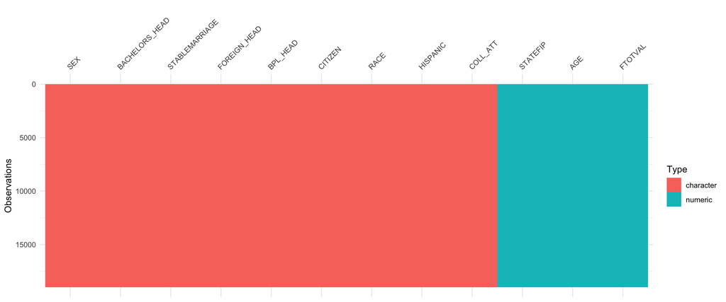

#### Binary Variables Changed to Factors

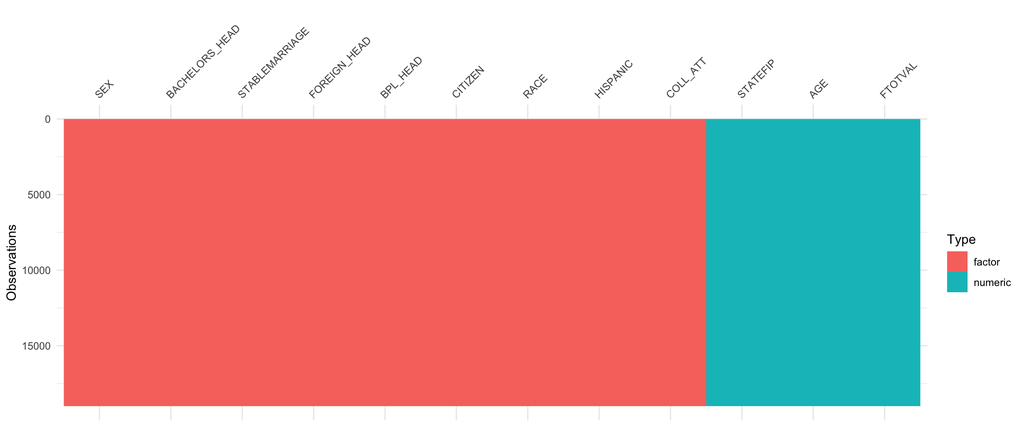

### 3.5. Check for Missing Values

The summary table indicated that some of the columns had missing values. Let’s check to see if there are still present even after doing some cleaning.

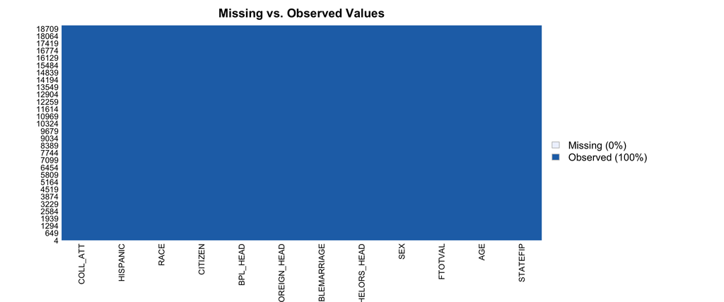

From the chart above, there are no missing values in our data. It seems removing respondents outside the age group we need and those with no incomes took care of the missing values.

### 3.6. Check for Duplicated Rows

The summary table above showed that there were duplicated rows. Let’s check to see if they are still present and consolidate them.

| Number of Duplicated Rows |
| --- |
| 419 |

Now, let’s keep only unique rows and confirm that all the duplicates have been delt with.

| Number of Duplicated Rows |
| --- |
| 0 |

## 4. Exploratory Data Analysis

Now that we have our final data for the analysis, let’s do some EDA.

### 4.1. Check for Multicollinearity

One of the main assumptions for logistic regressions is that there be no collinearity/multicollinearity among the explanatory variables. This means that the predictor variables must not have a high correlation or association. Hence, I check the correlation among all the variables I intend to use as predictor variables in the logistic regression model.

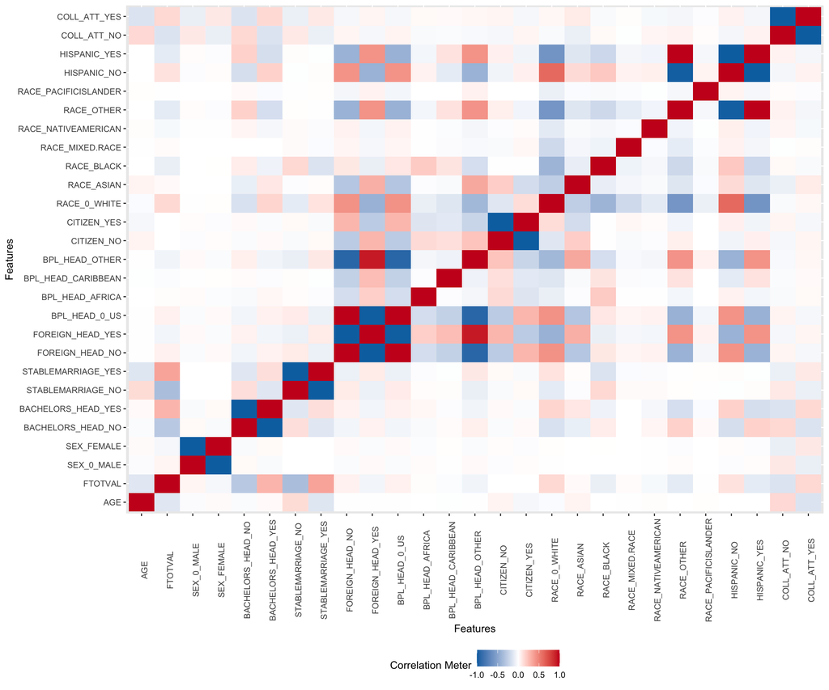

From the plot, there appear to be strong positive correlation between some pair of variables. `RACE_OTHER` and `HISPANICS` are highly correlated. This makes sense since most Hispanics probably identify as “other” when it comes to race.

There is also high correlation between the birth place of heads of household (BPL_HEAD) and their status as a foreigner (FOREIGN_HEAD). Again, this makes sense as most non-U.S. born heads of households are from other continents besides Africa and Caribbean.

It is important to keep track of which two or more variables are highly correlated. Using them as explanatory variables in the same model would cause multicollinearity issues, affecting the overall validity of the model.

## 5. Modeling: Logistic Regression

Using logit regression models, I attempt to answer the main question: **is there a difference in college enrollment rates between Native-born Blacks household children and African immigrants household children?**.

But before modeling enrollment rates among Black people, I look at college enrollment rates in the overall population with emphasis on the differences in enrollment rates between whites and other races and Hispanics. I also look at college enrollment rates in California to determine if the State’s ban on affirmative action in 1996 has had any impact on college enrollment rates.

The dependent variable for the regression is `COLL_ATT`.

### 5.1. Overall Enrollment Odds

Let’s start with enrollment rates in the overall sample and compare enrollment rates among other races to that of whites.

```
##
## Call:
## glm(formula = COLL_ATT ~ AGE + SEX + FTOTVAL + BACHELORS_HEAD +
##     STABLEMARRIAGE + RACE + HISPANIC, family = binomial(link = "logit"),
##     data = IPUMS)
##
## Deviance Residuals:
##     Min       1Q   Median       3Q      Max
## -2.8336  -0.9200  -0.7477   1.2642   2.1406
##
## Coefficients:
##                       Estimate Std. Error z value Pr(>|z|)
## (Intercept)          1.609e+00  1.536e-01  10.473  < 2e-16 ***
## AGE                 -1.299e-01  6.977e-03 -18.617  < 2e-16 ***
## SEXFEMALE            3.842e-01  3.169e-02  12.124  < 2e-16 ***
## FTOTVAL              2.425e-06  2.340e-07  10.360  < 2e-16 ***
## BACHELORS_HEADYES    5.072e-01  3.770e-02  13.452  < 2e-16 ***
## STABLEMARRIAGEYES    4.818e-02  3.476e-02   1.386 0.165766
## RACEASIAN            6.363e-01  6.732e-02   9.451  < 2e-16 ***
## RACEBLACK           -3.225e-02  5.096e-02  -0.633 0.526796
## RACEMIXED RACE       8.942e-02  9.618e-02   0.930 0.352523
## RACENATIVEAMERICAN  -7.125e-01  1.891e-01  -3.768 0.000164 ***
## RACEOTHER           -1.853e-01  2.618e-01  -0.708 0.479014
## RACEPACIFICISLANDER -2.047e-01  2.232e-01  -0.917 0.359057
## HISPANICYES          1.294e-01  2.589e-01   0.500 0.617016
## ---
## Signif. codes:  0 '***' 0.001 '**' 0.01 '*' 0.05 '.' 0.1 ' ' 1
##
## (Dispersion parameter for binomial family taken to be 1)
##
##     Null deviance: 24410  on 18777  degrees of freedom
## Residual deviance: 23203  on 18765  degrees of freedom
## AIC: 23229
##
## Number of Fisher Scoring iterations: 4
```

From the regression, the following variables are statistically significant at 95% confidence interval: `AGE`, `SEX(FEMALE)`, `FTOTVAL`, `BACHELORS_HEAD`, and `RACE (ASIAN & NATIVE AMERICAN)`. The aforementiond variable influence college enrollment odds - some positively, others negatively.

**Odds Ratio**

```
##         (Intercept)                 AGE           SEXFEMALE             FTOTVAL
##           4.9980399           0.8781926           1.4684601           1.0000024
##   BACHELORS_HEADYES   STABLEMARRIAGEYES           RACEASIAN           RACEBLACK
##           1.6605527           1.0493574           1.8894788           0.9682623
##      RACEMIXED RACE  RACENATIVEAMERICAN           RACEOTHER RACEPACIFICISLANDER
##           1.0935369           0.4903964           0.8308155           0.8149197
##         HISPANICYES
##           1.1382000
```

**Interpreting the Regression Results**

**Note:** Because they are not statistically significant, we cannot make any inferences about enrollment rates when comparing college enrollment among Blacks, Pacific Islanders, Hispanics, Mixed Race and Other races to that among Whites. We also cannot make any conclusion about the odds of enrollment for people coming from statble homes.

### 5.2. College Enrollment Among Californians

In 1996, the State of California banned the use of affirmative action. To test the effects of the ban on college enrollment rates, let’s restrict our sample in this regression to the state of California.

The size of the sample for our analysis is 2200.

```
##
## Call:
## glm(formula = COLL_ATT ~ AGE + SEX + FTOTVAL + RACE + HISPANIC +
##     BACHELORS_HEAD + STABLEMARRIAGE, family = binomial(link = "logit"),
##     data = IPUMS_CALI)
##
## Deviance Residuals:
##     Min       1Q   Median       3Q      Max
## -2.1869  -1.0429  -0.8291   1.2146   1.8320
##
## Coefficients:
##                       Estimate Std. Error z value Pr(>|z|)
## (Intercept)          2.437e+00  4.392e-01   5.548 2.88e-08 ***
## AGE                 -1.388e-01  1.983e-02  -6.998 2.60e-12 ***
## SEXFEMALE            3.151e-01  8.853e-02   3.559 0.000372 ***
## FTOTVAL              1.122e-06  5.940e-07   1.888 0.059002 .
## RACEASIAN            3.831e-01  1.538e-01   2.492 0.012702 *
## RACEBLACK           -3.668e-02  2.037e-01  -0.180 0.857068
## RACEMIXED RACE       7.578e-01  2.893e-01   2.619 0.008808 **
## RACENATIVEAMERICAN  -1.082e+00  8.128e-01  -1.331 0.183221
## RACEOTHER            4.795e-01  5.753e-01   0.834 0.404559
## RACEPACIFICISLANDER -3.203e-01  5.343e-01  -0.599 0.548919
## HISPANICYES         -7.269e-01  5.659e-01  -1.285 0.198933
## BACHELORS_HEADYES    1.554e-01  1.167e-01   1.332 0.182824
## STABLEMARRIAGEYES    1.350e-01  9.417e-02   1.433 0.151754
## ---
## Signif. codes:  0 '***' 0.001 '**' 0.01 '*' 0.05 '.' 0.1 ' ' 1
##
## (Dispersion parameter for binomial family taken to be 1)
##
##     Null deviance: 3015.6  on 2199  degrees of freedom
## Residual deviance: 2899.6  on 2187  degrees of freedom
## AIC: 2925.6
##
## Number of Fisher Scoring iterations: 4
```

**Odds Ratio**

```
##         (Intercept)                 AGE           SEXFEMALE             FTOTVAL
##          11.4365513           0.8704066           1.3704233           1.0000011
##           RACEASIAN           RACEBLACK      RACEMIXED RACE  RACENATIVEAMERICAN
##           1.4668978           0.9639843           2.1335949           0.3389883
##           RACEOTHER RACEPACIFICISLANDER         HISPANICYES   BACHELORS_HEADYES
##           1.6152338           0.7259535           0.4834042           1.1681600
##   STABLEMARRIAGEYES
##           1.1445206
```

### 5.3. College Enrollment Rates Among Black People

In the second part of this analysis, I take at college enrollment rates among black people only. To begin, let’s pull a subset respondents who identify solely as black and nothing else.

#### 5.3.1. Baseline Regression: Enrollment Rates Among Black People

First, I look at college enrollment odds among all black people.

```
##
## Call:
## glm(formula = COLL_ATT ~ AGE + SEX + FTOTVAL + BACHELORS_HEAD +
##     STABLEMARRIAGE, family = binomial(link = "logit"), data = IPUMS_BLK)
##
## Deviance Residuals:
##     Min       1Q   Median       3Q      Max
## -2.7263  -0.8697  -0.7178   1.2398   1.9768
##
## Coefficients:
##                     Estimate Std. Error z value Pr(>|z|)
## (Intercept)        2.891e-01  4.458e-01   0.649   0.5166
## AGE               -8.413e-02  2.060e-02  -4.084 4.44e-05 ***
## SEXFEMALE          6.071e-01  9.318e-02   6.515 7.27e-11 ***
## FTOTVAL            4.518e-06  9.421e-07   4.795 1.63e-06 ***
## BACHELORS_HEADYES  6.212e-01  1.202e-01   5.170 2.34e-07 ***
## STABLEMARRIAGEYES  2.286e-01  1.061e-01   2.154   0.0312 *
## ---
## Signif. codes:  0 '***' 0.001 '**' 0.01 '*' 0.05 '.' 0.1 ' ' 1
##
## (Dispersion parameter for binomial family taken to be 1)
##
##     Null deviance: 2926.2  on 2325  degrees of freedom
## Residual deviance: 2764.2  on 2320  degrees of freedom
## AIC: 2776.2
##
## Number of Fisher Scoring iterations: 4
```

**Odds Ratio**

```
##       (Intercept)               AGE         SEXFEMALE           FTOTVAL
##         1.3352525         0.9193131         1.8350230         1.0000045
## BACHELORS_HEADYES STABLEMARRIAGEYES
##         1.8612173         1.2568511
```

**Interpreting the Regression Results**

#### 5.3.2. Black Households with Foreigners as Head

What if the head of a black household is a foreigner, meaning they are not from the U.S. or any of its territories? Does that affect the odds of college enrollment for a black person from such a household?

```
##
## Call:
## glm(formula = COLL_ATT ~ AGE + SEX + FTOTVAL + BACHELORS_HEAD +
##     STABLEMARRIAGE + FOREIGN_HEAD, family = binomial(link = "logit"),
##     data = IPUMS_BLK)
##
## Deviance Residuals:
##    Min      1Q  Median      3Q     Max
## -2.599  -0.866  -0.706   1.206   1.999
##
## Coefficients:
##                     Estimate Std. Error z value Pr(>|z|)
## (Intercept)        2.059e-01  4.479e-01   0.460   0.6458
## AGE               -8.279e-02  2.067e-02  -4.005 6.20e-05 ***
## SEXFEMALE          6.179e-01  9.360e-02   6.601 4.07e-11 ***
## FTOTVAL            4.266e-06  9.427e-07   4.526 6.02e-06 ***
## BACHELORS_HEADYES  5.957e-01  1.207e-01   4.936 7.97e-07 ***
## STABLEMARRIAGEYES  2.052e-01  1.066e-01   1.925   0.0542 .
## FOREIGN_HEADYES    5.634e-01  1.342e-01   4.197 2.70e-05 ***
## ---
## Signif. codes:  0 '***' 0.001 '**' 0.01 '*' 0.05 '.' 0.1 ' ' 1
##
## (Dispersion parameter for binomial family taken to be 1)
##
##     Null deviance: 2926.2  on 2325  degrees of freedom
## Residual deviance: 2746.9  on 2319  degrees of freedom
## AIC: 2760.9
##
## Number of Fisher Scoring iterations: 4
```

**Odds Ratio**

```
##       (Intercept)               AGE         SEXFEMALE           FTOTVAL
##         1.2285950         0.9205414         1.8550405         1.0000043
## BACHELORS_HEADYES STABLEMARRIAGEYES   FOREIGN_HEADYES
##         1.8142718         1.2278002         1.7565551
```

#### 5.3.3. Does Citizenship matter for Black Enrollment Rates?

Let’s look citizenship status of the respondents. Does citizenship affect a black person’s chances of enrolling in college?

```
##
## Call:
## glm(formula = COLL_ATT ~ AGE + SEX + FTOTVAL + BACHELORS_HEAD +
##     STABLEMARRIAGE + FOREIGN_HEAD + CITIZEN, family = binomial(link = "logit"),
##     data = IPUMS_BLK)
##
## Deviance Residuals:
##    Min      1Q  Median      3Q     Max
## -2.599  -0.866  -0.706   1.206   1.999
##
## Coefficients:
##                     Estimate Std. Error z value Pr(>|z|)
## (Intercept)        2.091e-01  5.306e-01   0.394 0.693493
## AGE               -8.280e-02  2.068e-02  -4.003 6.25e-05 ***
## SEXFEMALE          6.179e-01  9.360e-02   6.601 4.07e-11 ***
## FTOTVAL            4.266e-06  9.429e-07   4.524 6.06e-06 ***
## BACHELORS_HEADYES  5.956e-01  1.207e-01   4.934 8.07e-07 ***
## STABLEMARRIAGEYES  2.052e-01  1.066e-01   1.925 0.054222 .
## FOREIGN_HEADYES    5.627e-01  1.472e-01   3.822 0.000132 ***
## CITIZENYES        -3.061e-03  2.689e-01  -0.011 0.990918
## ---
## Signif. codes:  0 '***' 0.001 '**' 0.01 '*' 0.05 '.' 0.1 ' ' 1
##
## (Dispersion parameter for binomial family taken to be 1)
##
##     Null deviance: 2926.2  on 2325  degrees of freedom
## Residual deviance: 2746.9  on 2318  degrees of freedom
## AIC: 2762.9
##
## Number of Fisher Scoring iterations: 4
```

**Odds Ratio**

```
##       (Intercept)               AGE         SEXFEMALE           FTOTVAL
##         1.2325786         0.9205343         1.8550375         1.0000043
## BACHELORS_HEADYES STABLEMARRIAGEYES   FOREIGN_HEADYES        CITIZENYES
##         1.8141966         1.2277773         1.7553466         0.9969437
```

#### 5.3.4. What if the Head of Household is an Immigrant?

In this section, I assess how college enrollment odds differ for black children with an immigrant as head of household compared to those with non-immigrant head of household. I pay particular to those with African or Caribbeans as head of household since majority of the black immigrant population come from African and Caribbean countries.

```
##
## Call:
## glm(formula = COLL_ATT ~ AGE + SEX + FTOTVAL + BACHELORS_HEAD +
##     STABLEMARRIAGE + BPL_HEAD, family = binomial(link = "logit"),
##     data = IPUMS_BLK)
##
## Deviance Residuals:
##     Min       1Q   Median       3Q      Max
## -2.5933  -0.8649  -0.7047   1.2064   2.0007
##
## Coefficients:
##                     Estimate Std. Error z value Pr(>|z|)
## (Intercept)        2.051e-01  4.481e-01   0.458  0.64715
## AGE               -8.295e-02  2.068e-02  -4.011 6.06e-05 ***
## SEXFEMALE          6.188e-01  9.370e-02   6.604 4.00e-11 ***
## FTOTVAL            4.257e-06  9.429e-07   4.515 6.32e-06 ***
## BACHELORS_HEADYES  5.954e-01  1.208e-01   4.931 8.20e-07 ***
## STABLEMARRIAGEYES  2.062e-01  1.067e-01   1.931  0.05344 .
## BPL_HEADAFRICA     5.807e-01  1.885e-01   3.080  0.00207 **
## BPL_HEADCARIBBEAN  5.701e-01  1.985e-01   2.873  0.00407 **
## BPL_HEADOTHER      6.646e-01  3.545e-01   1.875  0.06084 .
## ---
## Signif. codes:  0 '***' 0.001 '**' 0.01 '*' 0.05 '.' 0.1 ' ' 1
##
## (Dispersion parameter for binomial family taken to be 1)
##
##     Null deviance: 2926.2  on 2325  degrees of freedom
## Residual deviance: 2745.2  on 2317  degrees of freedom
## AIC: 2763.2
##
## Number of Fisher Scoring iterations: 4
```

**Odds Ratio**

```
##       (Intercept)               AGE         SEXFEMALE           FTOTVAL
##         1.2276315         0.9204001         1.8566887         1.0000043
## BACHELORS_HEADYES STABLEMARRIAGEYES    BPL_HEADAFRICA BPL_HEADCARIBBEAN
##         1.8137854         1.2289504         1.7872992         1.7684728
##     BPL_HEADOTHER
##         1.9437560
```

**Interpreting the Regression Results**

Literature (Bennett and Lutz, 2009) suggests that immigrant parents have higher educational attainments compared to parents of native blacks and that perhaps has an effect on the differences in college enrollment odds between their children.